# ML_Final_

**Binary Classifiers - Machine Learning and Foundations - Final Assignment**

*Importing required libraries*

```python
from google.colab import drive
drive.mount('/content/drive')
```

```python
import pandas as pd
import re
import string
import nltk
import numpy as np
import seaborn as sns
import matplotlib.pyplot as plt
from nltk.corpus import stopwords
from nltk.stem import WordNetLemmatizer
from collections import Counter
from sklearn.model_selection import train_test_split, GridSearchCV, cross_val_score, KFold
from sklearn.feature_extraction.text import TfidfVectorizer
from sklearn.ensemble import RandomForestClassifier
from sklearn.svm import SVC
from sklearn.metrics import classification_report, confusion_matrix, ConfusionMatrixDisplay, accuracy_score, f1_score
from imblearn.over_sampling import SMOTE
from sklearn.manifold import TSNE
import torch
import torch.nn as nn
import torch.optim as optim
from torch.utils.data import TensorDataset, DataLoader
import pickle
```

*Setting SEED to Ensure Reproducibility*

```python
# Seed and downloads
SEED = 42
nltk.download('stopwords')
nltk.download('wordnet')
nltk.download('punkt')
np.random.seed(SEED)
torch.manual_seed(SEED)
```

```
<torch._C.Generator at 0x793613d656b0>
```

```python
# Load and preprocess dataset
df = pd.read_csv('/content/drive/MyDrive/ML Final/2.csv')
df = df.drop(columns=['Unnamed: 0', 'authors', 'link', 'date'])
print(df.head())
df['combined_text'] = df['headline'] + " " + df['short_description']
df.drop(columns=['headline', 'short_description'], inplace=True)
df = df.dropna()
```

```
        category                                           headline  \
0  ENTERTAINMENT  This 'Catfight' Clip Pauses Anne Heche And San...
1  ENTERTAINMENT  Here's Why Parents Are Boycotting The New 'Pet...
2  ENTERTAINMENT  Justin Bieber And Lionel Richie's 17-Year-Old ...
3  ENTERTAINMENT  YouTube Suspends Ads From Logan Paul Videos Af...
4  ENTERTAINMENT     'Birdman' May Have Just Locked Up Best Picture

                                   short_description
0        There will be blood, but not in this scene.
1  Moviegoers have slammed the film for mocking t...
2                                    Hello? Goodbye.
3  The streaming service says Paul's channel is "...
4                                                NaN
```

Dropped authors, link and date as they won't be relevant to extract features from.

Function to clean the text data and prepare it for analysis.

```python
# Clean text
stop_words = set(stopwords.words('english'))
lemmatizer = WordNetLemmatizer()
def clean_text(text):
    text = text.lower()
    text = re.sub(r"[^a-zA-Z?.!,¿]+|http\S+", " ", text)
    text = ''.join([char for char in text if char not in string.punctuation])
    words = [word for word in text.split() if word not in stop_words]
    words = [lemmatizer.lemmatize(word) for word in words]
    return " ".join(words)
```

```python
df['cleaned_text'] = df['combined_text'].apply(clean_text)
```

The category distribution below shows an imbalance in our dataset where more articles are in the 'ENTERTAINMENT' category than in 'STYLE.' This means that the STYLE category is underrepresented in our dataset, this might lead to errors in classifying the articles from that category.

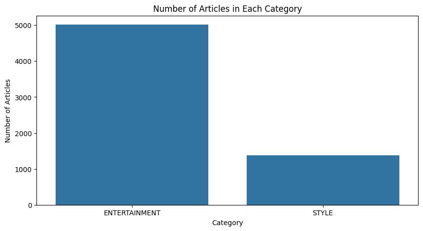

```python
# Plot category distribution
def plot_category_distribution(data):
    plt.figure(figsize=(10, 5))
    sns.countplot(data=data, x='category')
    plt.title('Number of Articles in Each Category')
    plt.xlabel('Category')
    plt.ylabel('Number of Articles')
    plt.show()

plot_category_distribution(df)
```

Plotting the most frequent words from both categories.

```python
# Plot most common words for each category
def plot_most_common_words(data, category, num_words=20):
    category_data = data[data['category'] == category]
    all_words = [word for text in category_data['cleaned_text'] for word in text.split()]
    word_freq = Counter(all_words).most_common(num_words)
    words, counts = zip(*word_freq)
    plt.figure(figsize=(10, 6))
    sns.barplot(x=counts, y=words, hue=words, palette='viridis')
    plt.title(f'Most Common Words in {category}')
    plt.xlabel('Frequency')
    plt.ylabel('Words')
    plt.show()
```

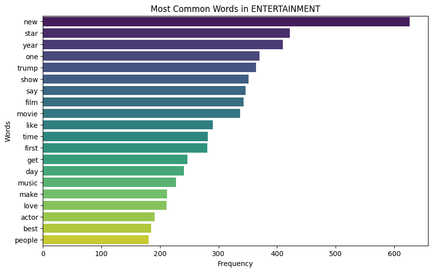

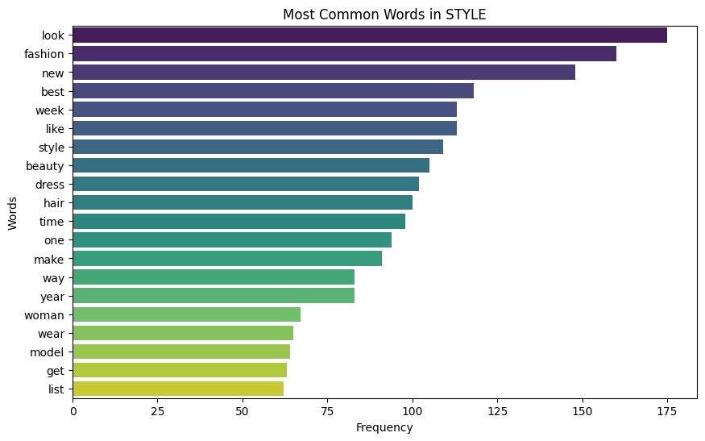

```python
categories = df['category'].unique()
for category in categories:
    plot_most_common_words(df, category)
```

Mapping the categorical variables to numbers for training purposes.

```python
# Prepare data for training
df_cleaned = df[['category', 'cleaned_text']].dropna()
category_mapping = {'ENTERTAINMENT': 0, 'STYLE': 1}
df_cleaned['category'] = df_cleaned['category'].map(category_mapping)
```

*Splitting the Data*: Our original dataset has been split into train, valid and test datasets in the ratio 70:15:15.

```python
train_data, test_data = train_test_split(df_cleaned, test_size=0.3, random_state=SEED, stratify=df_cleaned['category'])
valid_data, test_data = train_test_split(test_data, test_size=0.5, random_state=SEED, stratify=test_data['category'])
```

```python
# Save split datasets
train_data.to_csv('train.csv', index=False)
valid_data.to_csv('valid.csv', index=False)
test_data.to_csv('test.csv', index=False)
```

```python
# Load split datasets
train = pd.read_csv('train.csv')
valid = pd.read_csv('valid.csv')
```

Using TfIDF vectoriser to extract features from the text data. 'n_grams' is used to ensure that uni-grams and bi-grams are taken into consideration while extracting features. max_features is set to 5000 after trying a varied feature range while training models and 5000 was found to be the optimum feature size for the best F1 score.

**F1-Score:** is taken to be our primary metric as this takes into consideration both precision and recall when calculated. This ensures we acknowledge all the misclassifications when trying to improve the model performance.

```python
# Vectorize text data
tfidf_vectorizer = TfidfVectorizer(max_features=5000, ngram_range=(1,2))
x_train_vectorized = tfidf_vectorizer.fit_transform(train['cleaned_text'])
x_valid_vectorized = tfidf_vectorizer.transform(valid['cleaned_text'])
y_train = train['category']
y_valid = valid['category']
```

```
[t-SNE] Computing 121 nearest neighbors...
[t-SNE] Indexed 1000 samples in 0.003s...
[t-SNE] Computed neighbors for 1000 samples in 0.357s...
[t-SNE] Computed conditional probabilities for sample 1000 / 1000
[t-SNE] Mean sigma: 0.304060
[t-SNE] KL divergence after 50 iterations with early exaggeration: 66.978661
[t-SNE] KL divergence after 300 iterations: 2.050907
```

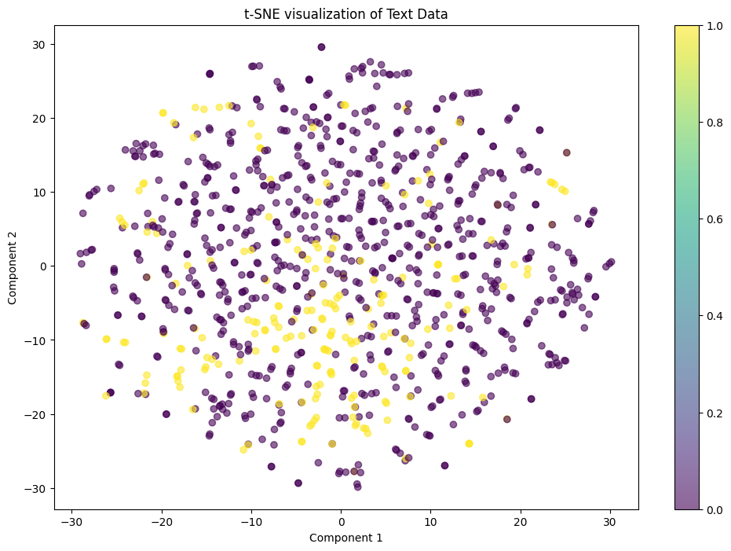

```python
n_samples = 1000
indices = np.random.choice(range(x_train_vectorized.shape[0]), size=n_samples, replace=False)
x_subset = x_train_vectorized[indices]
y_subset = y_train.iloc[indices]
tsne = TSNE(n_components=2, verbose=1, perplexity=40, n_iter=300)
tsne_results = tsne.fit_transform(x_subset.toarray())
plt.figure(figsize=(12, 8))
scatter = plt.scatter(tsne_results[:, 0], tsne_results[:, 1], c=y_subset, cmap='viridis', alpha=0.6)
plt.colorbar(scatter)
plt.title('t-SNE visualization of Text Data')
plt.xlabel('Component 1')
plt.ylabel('Component 2')
plt.show()
```

Training **Random Forest Classifier**

```python
def train_rf(x_train, y_train):
    rf = RandomForestClassifier(random_state=SEED)
    rf.fit(x_train, y_train)
    return rf
```

```python
rf = train_rf(x_train_vectorized, y_train)
```

Training **Support Vector Machine**

```python
def train_svm(x_train, y_train):
    svm = SVC(kernel='linear', random_state=SEED)
    svm.fit(x_train, y_train)
    return svm
```

Here we used linear kernel as it was giving the highest F1 Score, but we have to see as we go through the process.

```python
svm = train_svm(x_train_vectorized, y_train)
```

**End-to-end Deep Learning Model** All the parameters below were set to achieve the highest initial F1 score and will be changed if necessary.

```python
# Define neural network classifier
class TextClassifier(nn.Module):
    def __init__(self, input_dim, output_dim):
        super(TextClassifier, self).__init__()
        self.fc1 = nn.Linear(input_dim, 1024)
        self.fc2 = nn.Linear(1024, 512)
        self.fc3 = nn.Linear(512, 256)
        self.fc4 = nn.Linear(256, output_dim)
        self.relu = nn.ReLU()
        self.dropout = nn.Dropout(0.2)

    def forward(self, x):
        x = self.dropout(self.relu(self.fc1(x)))
        x = self.dropout(self.relu(self.fc2(x)))
        x = self.dropout(self.relu(self.fc3(x)))
        x = self.fc4(x)
        return x
```

```python
device = torch.device('cuda' if torch.cuda.is_available() else 'cpu')
x_train_tensor = torch.tensor(x_train_vectorized.toarray(), dtype=torch.float32)
y_train_tensor = torch.tensor(y_train.values, dtype=torch.long)
x_valid_tensor = torch.tensor(x_valid_vectorized.toarray(), dtype=torch.float32)
y_valid_tensor = torch.tensor(y_valid.values, dtype=torch.long)

train_dataset = TensorDataset(x_train_tensor, y_train_tensor)
train_loader = DataLoader(train_dataset, batch_size=64, shuffle=True)
```

```python
def train_nn(model, criterion, optimizer, train_loader, num_epochs):
    model.train()
    train_losses = []
    train_accuracies = []

    for epoch in range(1, num_epochs + 1):
        epoch_loss = 0.0
        epoch_true = 0
        epoch_total = 0

        for inputs, labels in train_loader:
            inputs, labels = inputs.to(device), labels.to(device)
            optimizer.zero_grad()
            outputs = model(inputs)
            loss = criterion(outputs, labels)
            loss.backward()
            optimizer.step()

            epoch_loss += loss.item()
            _, pred = torch.max(outputs, dim=1)
            epoch_true += torch.sum(pred == labels).item()
            epoch_total += labels.size(0)

        train_accuracy = 100 * epoch_true / epoch_total
        train_losses.append(epoch_loss)
        train_accuracies.append(train_accuracy)
        print(f"Epoch {epoch}/{num_epochs} finished: train_loss = {epoch_loss:.4f}, train_accuracy = {train_accuracy:.2f}%")

    return model
```

```python
input_dim = x_train_vectorized.shape[1]
categories = 2
model = TextClassifier(input_dim, categories).to(device)
criterion = nn.CrossEntropyLoss()
optimizer = optim.Adam(model.parameters(), lr=0.001)
trained_model = train_nn(model, criterion, optimizer, train_loader, num_epochs=15)
```

```python
# Evaluate models
def evaluate_model(model, x_train, y_train, x_valid, y_valid, model_name):
    y_train_pred = model.predict(x_train)
    train_accuracy = accuracy_score(y_train, y_train_pred)
    train_f1 = f1_score(y_train, y_train_pred)
    y_valid_pred = model.predict(x_valid)
    valid_accuracy = accuracy_score(y_valid, y_valid_pred)
    valid_f1 = f1_score(y_valid, y_valid_pred)
    print(f"{model_name} Performance:")
    print(f"Training Accuracy: {train_accuracy:.4f}, Training F1 Score: {train_f1:.4f}")
    print(f"Validation Accuracy: {valid_accuracy:.4f}, Validation F1 Score: {valid_f1:.4f}")
    print("Classification Report (Validation Set):")
    print(classification_report(y_valid, y_valid_pred))
    cnf_matrix = confusion_matrix(y_valid, y_valid_pred)
    disp = ConfusionMatrixDisplay(confusion_matrix=cnf_matrix)
    disp.plot(cmap='Blues_r')
    plt.title(f'Confusion Matrix ({model_name} - Validation Set)')
    plt.show()
    return train_accuracy, train_f1, valid_accuracy, valid_f1
```

```
Random Forest Performance:
Training Accuracy: 0.9998, Training F1 Score: 0.9995
Validation Accuracy: 0.9156, Validation F1 Score: 0.7939
Classification Report (Validation Set):
              precision    recall  f1-score   support

           0       0.93      0.96      0.95       752
           1       0.84      0.75      0.79       208

    accuracy                           0.92       960
   macro avg       0.89      0.86      0.87       960
weighted avg       0.91      0.92      0.91       960
```

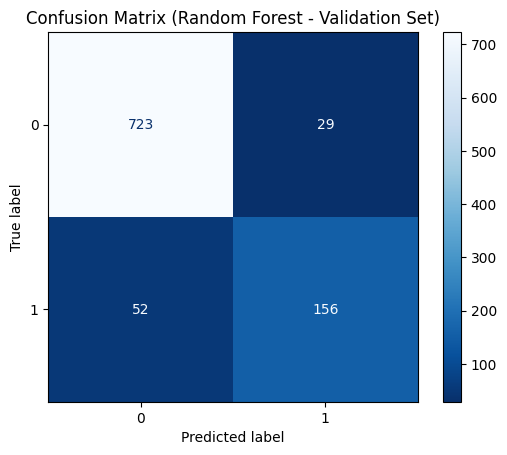

```python
# Evaluate standard Random Forest
rf_train_acc, rf_train_f1, rf_valid_acc, rf_valid_f1 = evaluate_model(rf, x_train_vectorized, y_train, x_valid_vectorized, y_valid, "Random Forest")
```

```
SVM Performance:
Training Accuracy: 0.9739, Training F1 Score: 0.9365
Validation Accuracy: 0.9156, Validation F1 Score: 0.7851
Classification Report (Validation Set):
              precision    recall  f1-score   support

           0       0.92      0.97      0.95       752
           1       0.88      0.71      0.79       208

    accuracy                           0.92       960
   macro avg       0.90      0.84      0.87       960
weighted avg       0.91      0.92      0.91       960
```

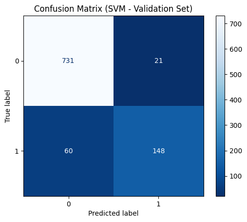

```python
# Evaluate SVM
svm_train_acc, svm_train_f1, svm_valid_acc, svm_valid_f1 = evaluate_model(svm, x_train_vectorized, y_train, x_valid_vectorized, y_valid, "SVM")
```

```python
# Evaluate neural network
def evaluate_nn(model, train_loader, x_valid_tensor, y_valid_tensor):
    model.eval()
    y_train_true = []
    y_train_pred = []
    for inputs, labels in train_loader:
        inputs, labels = inputs.to(device), labels.to(device)
        outputs = model(inputs)
        _, preds = torch.max(outputs, dim=1)
        y_train_true.extend(labels.cpu().numpy())
        y_train_pred.extend(preds.cpu().numpy())

    train_accuracy = accuracy_score(y_train_true, y_train_pred)
    train_f1 = f1_score(y_train_true, y_train_pred)

    with torch.no_grad():
        x_valid_tensor = x_valid_tensor.to(device)
        y_valid_tensor = y_valid_tensor.to(device)
        outputs = model(x_valid_tensor)
        _, y_valid_pred = torch.max(outputs, dim=1)

    valid_accuracy = accuracy_score(y_valid_tensor.cpu(), y_valid_pred.cpu())
    valid_f1 = f1_score(y_valid_tensor.cpu(), y_valid_pred.cpu())

    print(f"Neural Network Performance:")
    print(f"Training Accuracy: {train_accuracy:.4f}, Training F1 Score: {train_f1:.4f}")
    print(f"Validation Accuracy: {valid_accuracy:.4f}, Validation F1 Score: {valid_f1:.4f}")
    print("Classification Report (Validation Set):")
    print(classification_report(y_valid_tensor.cpu(), y_valid_pred.cpu()))
    cnf_matrix = confusion_matrix(y_valid_tensor.cpu(), y_valid_pred.cpu())
    disp = ConfusionMatrixDisplay(confusion_matrix=cnf_matrix)
    disp.plot(cmap='Blues_r')
    plt.title('Confusion Matrix (Neural Network - Validation Set)')
    plt.show()

    return train_accuracy, train_f1, valid_accuracy, valid_f1
```

```
Neural Network Performance:
Training Accuracy: 1.0000, Training F1 Score: 1.0000
Validation Accuracy: 0.8938, Validation F1 Score: 0.7560
Classification Report (Validation Set):
              precision    recall  f1-score   support

           0       0.93      0.93      0.93       752
           1       0.75      0.76      0.76       208

    accuracy                           0.89       960
   macro avg       0.84      0.85      0.84       960
weighted avg       0.89      0.89      0.89       960
```

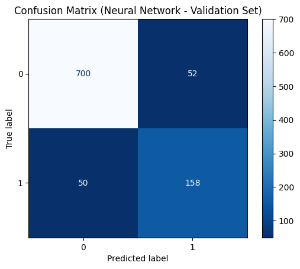

```python
# Evaluate Neural Network
nn_train_acc, nn_train_f1, nn_valid_acc, nn_valid_f1 = evaluate_nn(trained_model, train_loader, x_valid_tensor, y_valid_tensor)
```

From the above evaluation observations, Random Forest Classifier yielded the highest F1 score on validation data, i.e., 79.39%. SVM F1 score = 78.51% and Deep Learning Model = 75.60%

```python
# Error analysis
def error_analysis(model, x_data, y_data, data_text, model_name):
    predictions = model.predict(x_data)
    errors = np.where(predictions != y_data)[0]
    print(f"Error Analysis for {model_name}: {len(errors)} misclassifications out of {len(y_data)} samples")

    if len(errors) > 5:
        sample_errors = np.random.choice(errors, 5, replace=False)
    else:
        sample_errors = errors

    for i in sample_errors:
        print(f"\nIndex: {i}, Predicted: {predictions[i]}, Actual: {y_data[i]}")
        print(f"Text: {data_text.iloc[i]}")
    return errors
```

```python
rf_errors = error_analysis(rf, x_valid_vectorized, y_valid, valid['cleaned_text'], "Random Forest")
```

```
Error Analysis for Random Forest: 81 misclassifications out of 960 samples

Index: 491, Predicted: 0, Actual: 1
Text: let bask glory photo queen elizabeth ii driving car warning license

Index: 671, Predicted: 0, Actual: 1
Text: remembering tom petty year photo heartbreaking

Index: 281, Predicted: 0, Actual: 1
Text: online dating easy way fill date card guy increase chance response percent send email best time woman send email message pm pm

Index: 592, Predicted: 0, Actual: 1
Text: basic etiquette question test number list asked etiquette question includes business social quandary address test going list

Index: 437, Predicted: 1, Actual: 0
Text: spock guy spock guy calm rational funny understated way bluster observed solved problem hemingway style grace pressure admired
```

```python
svm_errors = error_analysis(svm, x_valid_vectorized, y_valid, valid['cleaned_text'], "SVM")
```

```
Error Analysis for SVM: 81 misclassifications out of 960 samples

Index: 385, Predicted: 1, Actual: 0
Text: khloe kardashian latest throwback photo absolutely purr fect probably best tbt yet

Index: 272, Predicted: 0, Actual: 1
Text: man bun outlawed byu campus extreme make u wonder jesus ever one

Index: 417, Predicted: 0, Actual: 1
Text: self tanner fail adidas written let happen

Index: 944, Predicted: 0, Actual: 1
Text: ciara show baby bump skintight black gown amas literally glowing

Index: 440, Predicted: 0, Actual: 1
Text: meghan markle jeweler making sure engagement ring stay one kind nothing like real thing baby
```

```python
def nn_error_analysis(model, loader, y_data, data_text, model_name):
    model.eval()
    predictions, actuals = [], []
    text_indices = []
    for batch, (inputs, labels) in enumerate(loader):
        inputs, labels = inputs.to(device), labels.to(device)
        outputs = model(inputs)
        _, preds = torch.max(outputs, dim=1)
        predictions.extend(preds.cpu().numpy())
        actuals.extend(labels.cpu().numpy())
        text_indices.extend(range(batch * loader.batch_size, batch * loader.batch_size + labels.size(0)))

    errors = np.where(np.array(predictions) != np.array(actuals))[0]
    print(f"Error Analysis for {model_name}: {len(errors)} misclassifications out of {len(actuals)} samples")

    if len(errors) > 5:
        sample_errors = np.random.choice(errors, 5, replace=False)
    else:
        sample_errors = errors

    for i in sample_errors:
        idx = text_indices[i]
        print(f"\nIndex: {idx}, Predicted: {predictions[i]}, Actual: {actuals[i]}")
        print(f"Text: {data_text.iloc[idx]}")
    return errors
```

```python
# Prepare DataLoader for validation set
valid_dataset = TensorDataset(x_valid_tensor, y_valid_tensor)
valid_loader = DataLoader(valid_dataset, batch_size=64, shuffle=False)
```

```python
# Perform error analysis on validation set for Neural Network
nn_errors_valid = nn_error_analysis(trained_model, valid_loader, y_valid, valid['cleaned_text'], "Neural Network - Validation")
```

```
Error Analysis for Neural Network - Validation: 102 misclassifications out of 960 samples

Index: 219, Predicted: 0, Actual: 1
Text: blake lively rocked delightful fake lob actually pretty easy achieve

Index: 802, Predicted: 0, Actual: 1
Text: dispatch true cost nyc premier miriam ava founder colorsofgratitudecom ambassador good taste share message matter one dispatch time view utterly intrinsically independent love share hope enjoy

Index: 936, Predicted: 1, Actual: 0
Text: promised tiffany haddish wore white snl gown oscar star walked red carpet traditional eritrea princess gown changed old favorite presented

Index: 7, Predicted: 1, Actual: 0
Text: attention drake reason jennifer lopez date younger men appreciate way age

Index: 495, Predicted: 0, Actual: 1
Text: naomi campbell show emmy red carpet done va va voom
```

To try and negate this issue of underrepresentation, a couple of approaches were adopted.

**Weighted Samples**

```python
# Refined models with class_weight='balanced'
def refined_train_rf(x_train, y_train):
    refined_rf = RandomForestClassifier(n_estimators=1000, class_weight='balanced', random_state=SEED)
    refined_rf.fit(x_train, y_train)
    return refined_rf
```

```python
refined_rf = refined_train_rf(x_train_vectorized, y_train)
```

```python
def refined_train_svm(x_train, y_train):
    refined_svm = SVC(kernel='linear', class_weight='balanced', random_state=SEED)
    refined_svm.fit(x_train, y_train)
    return refined_svm
```

```python
refined_svm = refined_train_svm(x_train_vectorized, y_train)
```

```
Refined Random Forest Performance:
Training Accuracy: 1.0000, Training F1 Score: 1.0000
Validation Accuracy: 0.9104, Validation F1 Score: 0.7806
Classification Report (Validation Set):
              precision    recall  f1-score   support

           0       0.93      0.96      0.94       752
           1       0.83      0.74      0.78       208

    accuracy                           0.91       960
   macro avg       0.88      0.85      0.86       960
weighted avg       0.91      0.91      0.91       960
```

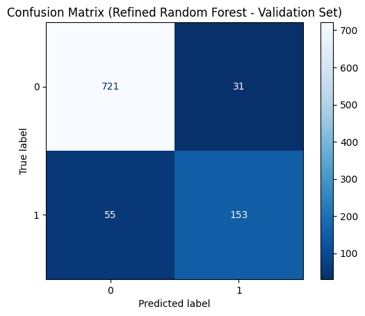

```python
# Evaluate refined models
refined_rf_train_acc, refined_rf_train_f1, refined_rf_valid_acc, refined_rf_valid_f1 = evaluate_model(refined_rf, x_train_vectorized, y_train, x_valid_vectorized, y_valid, "Refined Random Forest")
```

```
Refined SVM Performance:
Training Accuracy: 0.9792, Training F1 Score: 0.9538
Validation Accuracy: 0.9021, Validation F1 Score: 0.7793
Classification Report (Validation Set):
              precision    recall  f1-score   support

           0       0.94      0.93      0.94       752
           1       0.76      0.80      0.78       208

    accuracy                           0.90       960
   macro avg       0.85      0.86      0.86       960
weighted avg       0.90      0.90      0.90       960
```

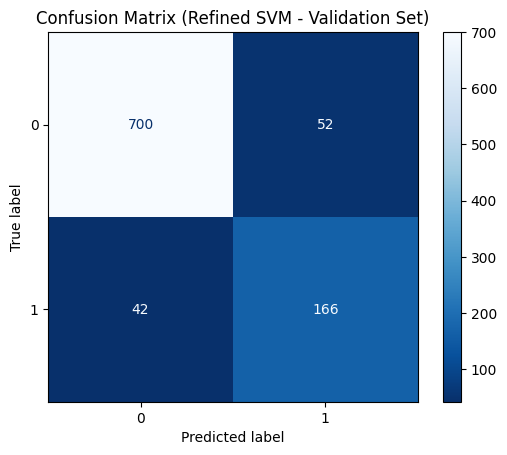

```python
refined_svm_train_acc, refined_svm_train_f1, refined_svm_valid_acc, refined_svm_valid_f1 = evaluate_model(refined_svm, x_train_vectorized, y_train, x_valid_vectorized, y_valid, "Refined SVM")
```

```python
# Neural network with weighted sampler
from torch.utils.data import WeightedRandomSampler

def create_sampler(y_train):
    class_counts = np.bincount(y_train)
    class_weights = 1. / class_counts
    sample_weights = class_weights[y_train]
    sampler = WeightedRandomSampler(weights=sample_weights, num_samples=len(sample_weights), replacement=True)
    return sampler

train_sampler = create_sampler(y_train_tensor.numpy())
train_dataset = TensorDataset(x_train_tensor, y_train_tensor)
train_loader = DataLoader(train_dataset, batch_size=64, shuffle=False, sampler=train_sampler)

refined_model = TextClassifier(input_dim, categories).to(device)
optimizer = optim.Adam(refined_model.parameters(), lr=0.001)
refined_trained_model = train_nn(refined_model, criterion, optimizer, train_loader, num_epochs=10)
```

```
Neural Network Performance:
Training Accuracy: 0.9998, Training F1 Score: 0.9998
Validation Accuracy: 0.9104, Validation F1 Score: 0.7737
Classification Report (Validation Set):
              precision    recall  f1-score   support

           0       0.92      0.97      0.94       752
           1       0.85      0.71      0.77       208

    accuracy                           0.91       960
   macro avg       0.89      0.84      0.86       960
weighted avg       0.91      0.91      0.91       960
```

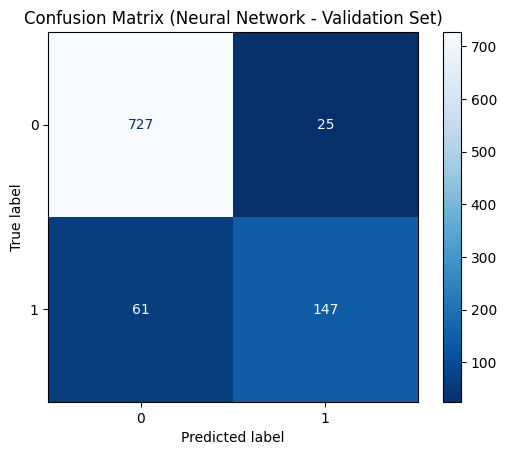

```python
refined_nn_train_acc, refined_nn_train_f1, refined_nn_valid_acc, refined_nn_valid_f1 = evaluate_nn(refined_trained_model, train_loader, x_valid_tensor, y_valid_tensor)
```

Weighted samples did not prove to be useful as the F1 scores were worse compared to before. But the deep learning model's performance has improved noticeably from F1 Score 75.6% to 77.37%

Below is a combination of **Synthetic Minority Oversampling Technique (SMOTE)** and **Hyperparameter Tuning**

```python
# SMOTE for imbalanced data
smote = SMOTE(random_state=SEED)
x_train_smote, y_train_smote = smote.fit_resample(x_train_vectorized, y_train)
```

```python
param_grid_rf = {
    'n_estimators': [300, 500],
    'min_samples_split': [2, 5, 10],
    'class_weight': ['balanced']
}
rf = RandomForestClassifier(random_state=SEED)

grid_search_rf = GridSearchCV(estimator=rf, param_grid=param_grid_rf, cv=5, verbose=2, scoring='accuracy', n_jobs=-1)

refined_rf_smote = grid_search_rf.fit(x_train_smote, y_train_smote)
```

```
Fitting 5 folds for each of 6 candidates, totalling 30 fits
```

```
Refined Random Forest with SMOTE Performance:
Training Accuracy: 1.0000, Training F1 Score: 1.0000
Validation Accuracy: 0.9052, Validation F1 Score: 0.7797
Classification Report (Validation Set):
              precision    recall  f1-score   support

           0       0.94      0.94      0.94       752
           1       0.79      0.77      0.78       208

    accuracy                           0.91       960
   macro avg       0.86      0.86      0.86       960
weighted avg       0.90      0.91      0.90       960
```

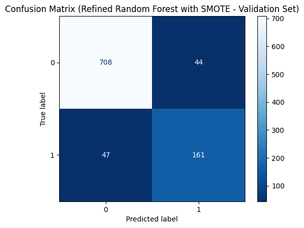

```python
# Evaluate Random Forest with SMOTE
refined_rf_smote_train_acc, refined_rf_smote_train_f1, refined_rf_smote_valid_acc, refined_rf_smote_valid_f1 = evaluate_model(refined_rf_smote, x_train_smote, y_train_smote, x_valid_vectorized, y_valid, "Refined Random Forest with SMOTE")
```

```python
param_grid_svm = {
    'C': [0.1, 1, 10],
    'kernel': ['linear', 'rbf', 'sigmoid'],
    'class_weight': ['balanced']
}

# Initialize the SVM classifier
svm = SVC(random_state=SEED)

# Create the GridSearchCV object for SVM
grid_search_svm = GridSearchCV(estimator=svm, param_grid=param_grid_svm, cv=5, verbose=2, scoring='accuracy', n_jobs=-1)

# Fit the grid search to the data
svm_smote = grid_search_svm.fit(x_train_smote, y_train_smote)
```

```
Fitting 5 folds for each of 9 candidates, totalling 45 fits
```

```
SVM with SMOTE Performance:
Training Accuracy: 0.9897, Training F1 Score: 0.9898
Validation Accuracy: 0.9062, Validation F1 Score: 0.7826
Classification Report (Validation Set):
              precision    recall  f1-score   support

           0       0.94      0.94      0.94       752
           1       0.79      0.78      0.78       208

    accuracy                           0.91       960
   macro avg       0.86      0.86      0.86       960
weighted avg       0.91      0.91      0.91       960
```

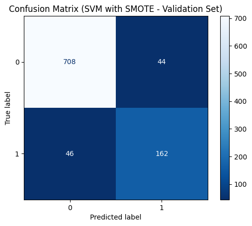

```python
# Evaluate SVM with SMote
svm_smote_train_acc, svm_smote_train_f1, svm_smote_valid_acc, svm_smote_valid_f1 = evaluate_model(svm_smote, x_train_smote, y_train_smote, x_valid_vectorized, y_valid, "SVM with SMOTE")
```

```
Neural Network Performance:
Training Accuracy: 1.0000, Training F1 Score: 1.0000
Validation Accuracy: 0.9083, Validation F1 Score: 0.7720
Classification Report (Validation Set):
              precision    recall  f1-score   support

           0       0.92      0.96      0.94       752
           1       0.84      0.72      0.77       208

    accuracy                           0.91       960
   macro avg       0.88      0.84      0.86       960
weighted avg       0.91      0.91      0.91       960
```

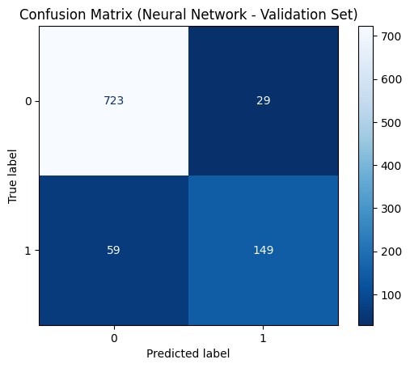

```python
# Convert SMOTE data to tensors for Neural Network training
x_train_smote_tensor = torch.tensor(x_train_smote.toarray(), dtype=torch.float32)
y_train_smote_tensor = torch.tensor(y_train_smote, dtype=torch.long)

# DataLoader with SMOTE data
train_dataset_smote = TensorDataset(x_train_smote_tensor, y_train_smote_tensor)
train_loader_smote = DataLoader(train_dataset_smote, batch_size=64, shuffle=True)

nn_smote_model = TextClassifier(input_dim=x_train_smote_tensor.shape[1], output_dim=len(np.unique(y_train_smote))).to(device)
optimizer = optim.Adam(nn_smote_model.parameters(), lr=0.001)
criterion = nn.CrossEntropyLoss()
trained_nn_smote = train_nn(nn_smote_model, criterion, optimizer, train_loader_smote, num_epochs=10)
smote_nn_train_acc, smote_nn_train_f1, smote_nn_valid_acc, smote_nn_valid_f1 = evaluate_nn(trained_nn_smote, train_loader, x_valid_tensor, y_valid_tensor)
```

**Saving the models**

```python
best_rf_model = grid_search_rf.best_estimator_

with open('best_rf_model.pkl', 'wb') as file:
    pickle.dump(best_rf_model, file)
```

```python
best_svm_model = grid_search_svm.best_estimator_

with open('best_svm_model.pkl', 'wb') as file:
    pickle.dump(best_svm_model, file)
```

```python
torch.save(nn_smote_model.state_dict(), 'nn_smote_model.pth')
```

```python
with open('best_rf_model.pkl', 'rb') as file:
    loaded_rf_model = pickle.load(file)

with open('best_svm_model.pkl', 'rb') as file:
    loaded_svm_model = pickle.load(file)
```

**Combining the train and validation sets to perform cross validation on models**

```python
# Merge train and validation datasets
train_val_combined = pd.concat([train_data, valid_data])

# Preprocess text data as previously done
X_train_val = tfidf_vectorizer.transform(train_val_combined['cleaned_text'])
y_train_val = train_val_combined['category']

# Perform cross-validation on the loaded RF and SVM models
rf_scores = cross_val_score(loaded_rf_model, X_train_val, y_train_val, cv=5, scoring='accuracy')
svm_scores = cross_val_score(loaded_svm_model, X_train_val, y_train_val, cv=5, scoring='accuracy')

print("Random Forest average cross-validation score:", np.mean(rf_scores))
print("SVM average cross-validation score:", np.mean(svm_scores))
```

```
Random Forest average cross-validation score: 0.899798758049678
SVM average cross-validation score: 0.9113794712917367
```

```python
model = TextClassifier(input_dim, categories)
model.load_state_dict(torch.load('nn_smote_model.pth'))
model.to(device)
model.eval()
X_train_val_vectorized = tfidf_vectorizer.transform(train_val_combined['cleaned_text'])
X_train_val_tensor = torch.tensor(X_train_val_vectorized.toarray(), dtype=torch.float32)
y_train_val_tensor = torch.tensor(y_train_val.values, dtype=torch.long)
full_dataset = TensorDataset(X_train_val_tensor, y_train_val_tensor)
full_loader = DataLoader(full_dataset, batch_size=64, shuffle=False)
```

*KFold Cross Validation for Deep Learning Model*

```python
def evaluate_kfold_nn(model, test_loader):
    model.eval()
    total = 0
    correct = 0
    y_true = []
    y_pred = []
    with torch.no_grad():
        for inputs, labels in test_loader:
            inputs, labels = inputs.to(device), labels.to(device)
            outputs = model(inputs)
            _, predicted = torch.max(outputs.data, 1)
            total += labels.size(0)
            correct += (predicted == labels).sum().item()
            y_true.extend(labels.cpu().numpy())
            y_pred.extend(predicted.cpu().numpy())

    accuracy = correct / total
    f1 = f1_score(y_true, y_pred, average='weighted')
    return accuracy, f1
```

```python
def cross_validate_nn(model, dataset, k_folds=5):
    kf = KFold(n_splits=k_folds, shuffle=True, random_state=SEED)
    accuracies = []
    f1_scores = []

    for train_idx, test_idx in kf.split(dataset):
        # Create data loaders for the current fold
        test_subsampler = torch.utils.data.SubsetRandomSampler(test_idx)
        test_loader = DataLoader(dataset, batch_size=64, sampler=test_subsampler)

        # Evaluate the model
        model.eval()  # Ensure the model is in evaluation mode
        accuracy, f1 = evaluate_kfold_nn(model, test_loader)  # Adjust 'evaluate_nn' to handle a single loader
        accuracies.append(accuracy)
        f1_scores.append(f1)

    print(f"Average Accuracy: {np.mean(accuracies)}")
    print(f"Average F1 Score: {np.mean(f1_scores)}")

# Execute the cross-validation
cross_validate_nn(model, full_dataset)
```

```
Average Accuracy: 0.9838213309702905
Average F1 Score: 0.983743975171414
```

After merging the train and valid datasets and performing cross validation, the deep-learning model has a higher Average Cross Validation F1 score of 98.4%.

Taking the high CV F1 Score into consideration, the deep learning model was evaluated with the test dataset below.

```python
model = TextClassifier(input_dim, categories)
model.load_state_dict(torch.load('nn_smote_model.pth'))
model.to(device)
model.eval()
```

```
TextClassifier(
  (fc1): Linear(in_features=5000, out_features=1024, bias=True)
  (fc2): Linear(in_features=1024, out_features=512, bias=True)
  (fc3): Linear(in_features=512, out_features=256, bias=True)
  (fc4): Linear(in_features=256, out_features=2, bias=True)
  (relu): ReLU()
  (dropout): Dropout(p=0.2, inplace=False)
)
```

```python
X_test_vectorized = tfidf_vectorizer.transform(test_data['cleaned_text'])
X_test_tensor = torch.tensor(X_test_vectorized.toarray(), dtype=torch.float32)
y_test_tensor = torch.tensor(test_data['category'].values, dtype=torch.long)

# Create a DataLoader for the test set
test_dataset = TensorDataset(X_test_tensor, y_test_tensor)
test_loader = DataLoader(test_dataset, batch_size=64, shuffle=False)
```

```python
def test_evaluate_nn(model, loader):
    model.eval()
    correct = 0
    total = 0
    y_true = []
    y_pred = []

    with torch.no_grad():
        for inputs, labels in loader:
            inputs, labels = inputs.to(device), labels.to(device)
            outputs = model(inputs)
            _, predicted = torch.max(outputs.data, 1)
            total += labels.size(0)
            correct += (predicted == labels).sum().item()
            y_true.extend(labels.cpu().numpy())
            y_pred.extend(predicted.cpu().numpy())

    accuracy = correct / total
    f1 = f1_score(y_true, y_pred, average='weighted')
    print(f"Accuracy: {accuracy:.4f}")
    print(f"F1 Score: {f1:.4f}")
    print("Classification Report:")
    print(classification_report(y_true, y_pred))
    return accuracy, f1
```

```python
accuracy, f1 = test_evaluate_nn(model, test_loader)
```

```
Accuracy: 0.9135
F1 Score: 0.9115
Classification Report:
              precision    recall  f1-score   support

           0       0.93      0.96      0.95       753
           1       0.84      0.74      0.79       207

    accuracy                           0.91       960
   macro avg       0.89      0.85      0.87       960
weighted avg       0.91      0.91      0.91       960
```

We achieved an F1 score of 91.15% without retraining it with the combined dataset of train and valid.

**Training the model on Combined Dataset and evaluating its performance on Test data**

```python
train_val_dataset = TensorDataset(X_train_val_tensor, y_train_val_tensor)
train_val_loader = DataLoader(train_val_dataset, batch_size=64, shuffle=True)
model = TextClassifier(input_dim, categories)
model.to(device)
model.train()
criterion = nn.CrossEntropyLoss()
optimizer = optim.Adam(model.parameters(), lr=0.001)
train_nn(model, criterion, optimizer, train_val_loader, num_epochs=15)
```

```
TextClassifier(
  (fc1): Linear(in_features=5000, out_features=1024, bias=True)
  (fc2): Linear(in_features=1024, out_features=512, bias=True)
  (fc3): Linear(in_features=512, out_features=256, bias=True)
  (fc4): Linear(in_features=256, out_features=2, bias=True)
  (relu): ReLU()
  (dropout): Dropout(p=0.2, inplace=False)
)
```

```python
accuracy, f1 = test_evaluate_nn(model, test_loader)
```

```
Accuracy: 0.9167
F1 Score: 0.9162
Classification Report:
              precision    recall  f1-score   support

           0       0.94      0.95      0.95       753
           1       0.82      0.79      0.80       207

    accuracy                           0.92       960
   macro avg       0.88      0.87      0.88       960
weighted avg       0.92      0.92      0.92       960
```